# Assignment 2

Huang Yingshan, Kahlbacher Fabian, Wattenberg Yannick, Aggeler Samuel

10/11/2021

# Task 2

```r
set.seed(123)
```

```r
lawyeradvice <- as.matrix(read.csv("data/lawyeradvice.csv", header=FALSE))
lawyeradvice <- lawyeradvice[2:37, 2:37]
colnames(lawyeradvice) <- 1:36
rownames(lawyeradvice) <- 1:36

lawyerattr <- read.csv("data/lawyerattr.csv", header=TRUE)
```

## 1)

```r
#library(sna)
library(network)
library(ergm)
```

```r
netw <- network(lawyeradvice, directed=TRUE)
netw %v% "gender" <- lawyerattr$gender
netw %v% "office_location" <- lawyerattr$office_location
netw %v% "seniority" <- lawyerattr$seniority
```

```r
model_gender <- ergm(netw ~ edges + nodematch('gender'))
```

```
## Starting maximum pseudolikelihood estimation (MPLE):
```

```
## Evaluating the predictor and response matrix.
```

```
## Maximizing the pseudolikelihood.
```

```
## Finished MPLE.
```

```
## Stopping at the initial estimate.
```

```
## Evaluating log-likelihood at the estimate.
```

```r
summary(model_gender)
```

```
## Call:
## ergm(formula = netw ~ edges + nodematch("gender"))
##
## Iterations:  4 out of 20
##
## Monte Carlo MLE Results:
##                  Estimate Std. Error MCMC % z value Pr(>|z|)
## edges             -0.8569     0.1554      0  -5.515   <1e-04 ***
## nodematch.gender   0.0865     0.1688      0   0.512    0.608
## ---
## Signif. codes:  0 '***' 0.001 '**' 0.01 '*' 0.05 '.' 0.1 ' ' 1
##
##      Null Deviance: 1747  on 1260  degrees of freedom
##  Residual Deviance: 1567  on 1258  degrees of freedom
##
## AIC: 1571    BIC: 1581    (Smaller is better.)
```

According to the estimates from the ERGM gender homophily is not statistically significant on the 5% significance level. Thus, it seems that the probability of a tie (asking for advice) does not change if lawyers are of the same or of different gender.

```r
N1 <- sum(lawyerattr$gender == 1)
N2 <- sum(lawyerattr$gender == 2)

tot_same_gender <- N1*(N1-1) + N2*(N2-1)

idx1 <- which(lawyerattr$gender==1)
idx2 <- which(lawyerattr$gender==2)
same_gender_and_tie <- sum(lawyeradvice[idx1, idx1]) + sum(lawyeradvice[idx2, idx2])

same_gender_and_tie / tot_same_gender
```

```
## [1] 0.3163842
```

The conditional probability of observing a tie between two employees i and j which have the same gender is 0.3163842.

```r
# probability of observing a tie
theta1 <- model_gender$coef['edges']
p <- exp(theta1)/(1+exp(theta1))
```

The probability of a tie if we do not condition on same gender of lawyers is 0.2979798. Which is about the same as the conditional probability of a tie if lawyers are from the same gender. This is expected since gender homophily is not significant in the model above.

## 2)

```r
model2 <- ergm(
  netw ~
    edges +
    mutual +
    gwesp(decay=0.3,fixed=TRUE) + # caution: against transitivity
    nodematch('office_location') +
    nodematch('gender') +
    nodeocov('seniority') +
    nodeicov('seniority') +
    absdiff('seniority')
)
```

```
## Starting maximum pseudolikelihood estimation (MPLE):
```

```
## Evaluating the predictor and response matrix.
```

```
## Maximizing the pseudolikelihood.
```

```
## Finished MPLE.
```

```
## Starting Monte Carlo maximum likelihood estimation (MCMLE):
```

```
## Iteration 1 of at most 20:
```

```
## Optimizing with step length 0.744324859436967.
```

```
## The log-likelihood improved by 3.585.
```

```
## Iteration 2 of at most 20:
```

```
## Optimizing with step length 1.
```

```
## The log-likelihood improved by 0.3071.
```

```
## Step length converged once. Increasing MCMC sample size.
```

```
## Iteration 3 of at most 20:
```

```
## Optimizing with step length 1.
```

```
## The log-likelihood improved by 0.00983.
```

```
## Step length converged twice. Stopping.
```

```
## Finished MCMLE.
```

```
## Evaluating log-likelihood at the estimate. Using 20 bridges: 1 2 3 4 5 6 7 8 9 10 11 12 13 14 15 16 17 18 19 20 .
## This model was fit using MCMC.  To examine model diagnostics and check
## for degeneracy, use the mcmc.diagnostics() function.
```

## 3)

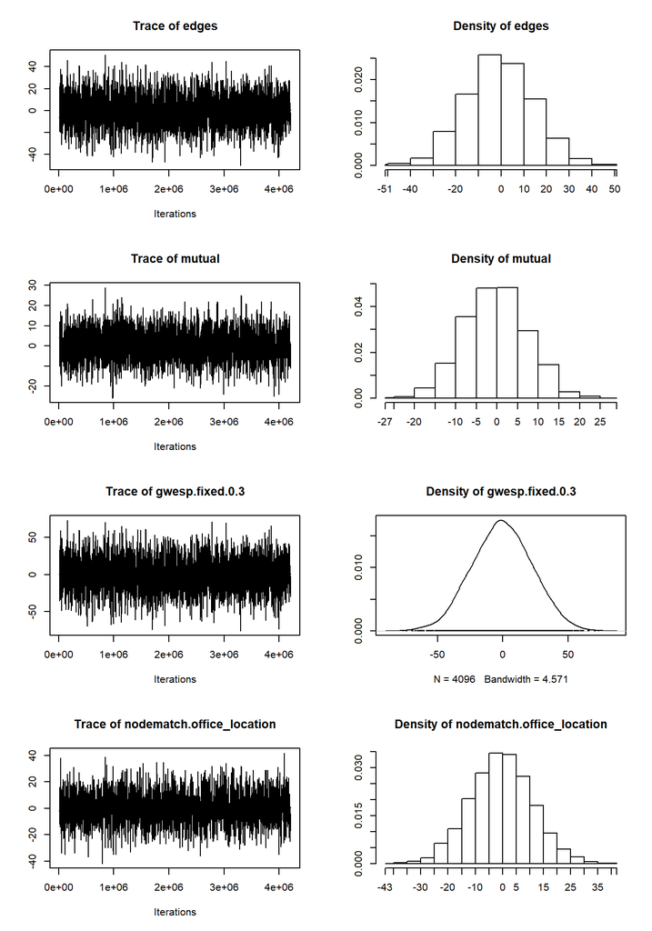

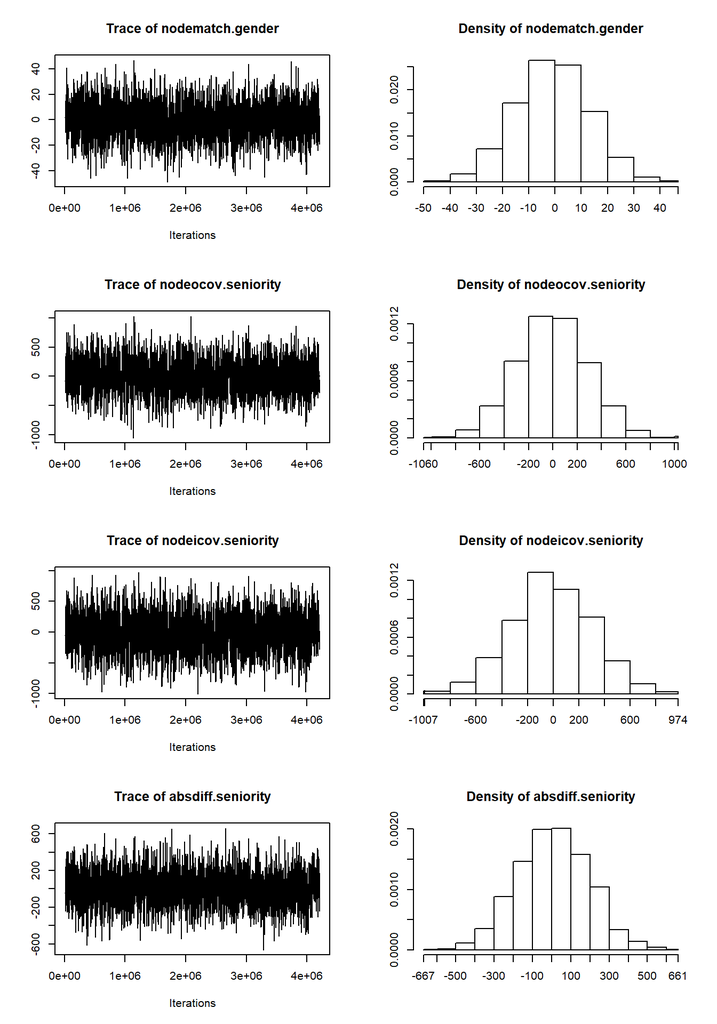

[output not shown]

```r
mcmc.diagnostics(model2, which="plots")
```

The MCMC algorithm converged after three iterations. The model diagnostics look well as the attributes (sufficient statistics) of the simulated networks have low auto correlation and are more or less normally distributed.

## 4)

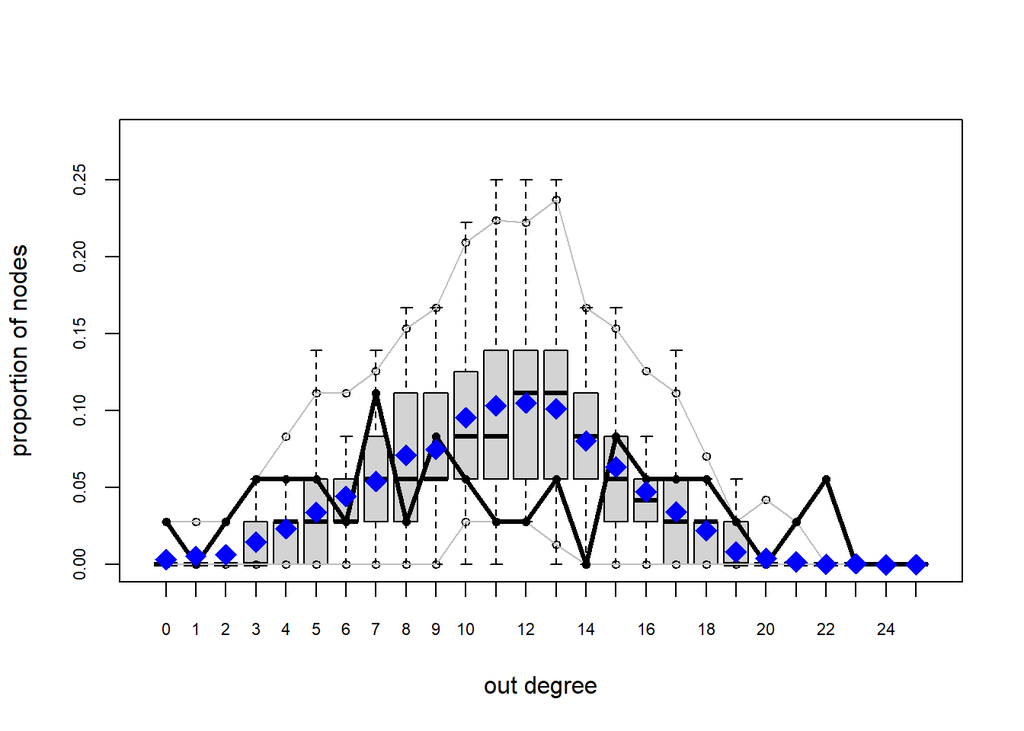

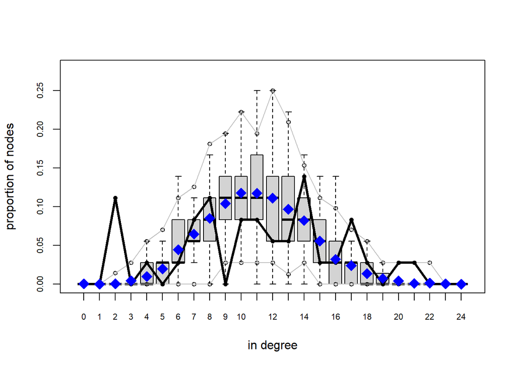

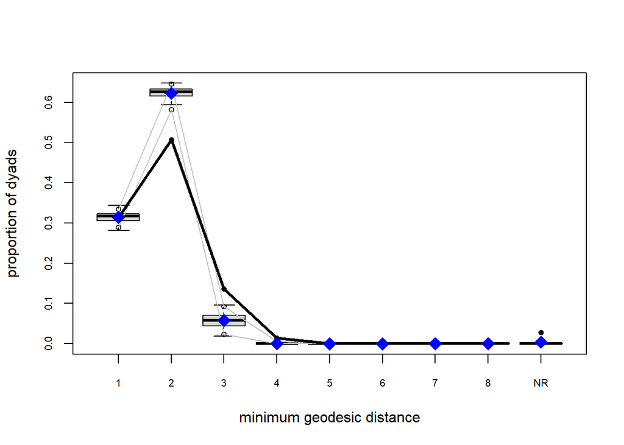

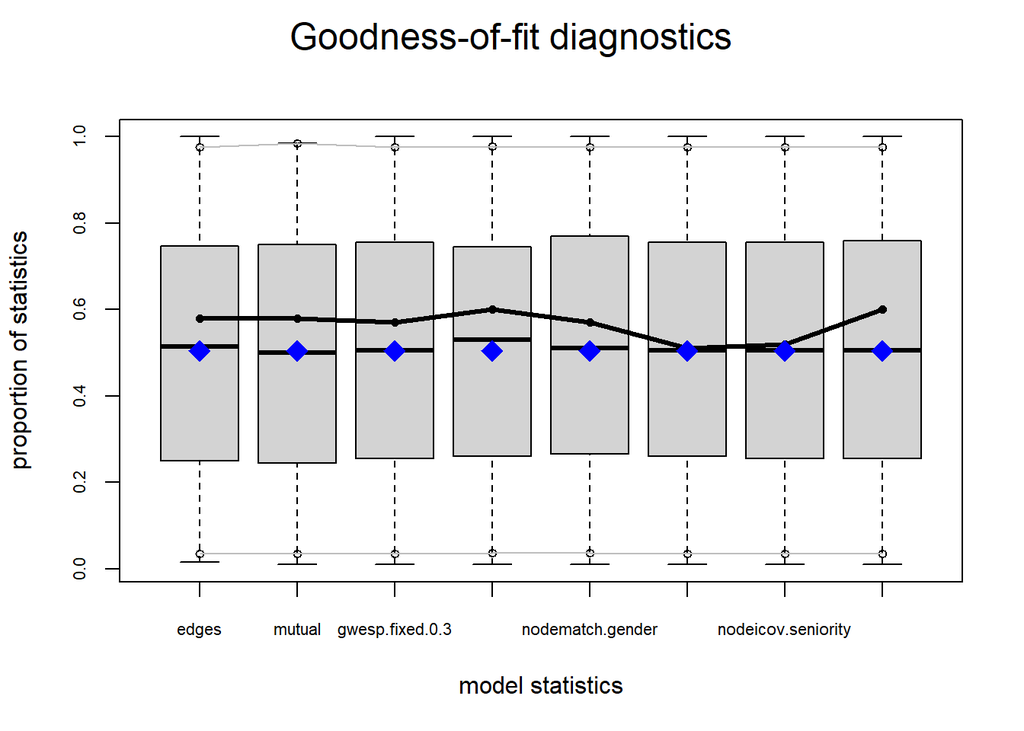

```r
model2gof <- gof(model2 ~ odegree + idegree + distance + model)
plot(model2gof)
```

Evaluation of GOF of the specified ERGM model: Desired property of the GOF plots: The observed values (black) should be centered in the simulated values. Which means they should be more or less close to the median and in the 95% confidence interval (grey lines) of the corresponding simulated statistics.

- out degree: The observed values of the out degree are mostly very similar to the simulated ones. There is a spike at a out degree of 21/22 which is not any more in the confidence interval of the simulated values. The observed values of the out degrees of 1, 3, 14, 20 are at the boundary of the confidence interval of the simulated values.
- in degree: The observed values of the in degree are mostly very similar to the simulated ones. There is a spike at the in degrees of 2 and 9 which are not any more in the confidence interval of the simulated values. The observed values of the in degrees of 3, 5, 17, 20, 21 are at the boundary of the confidence interval of the simulated values.
- minimum geodesic distance: The observed values do not fit the simulated values very well. However, the general trend is preserved among different distances. Especially, a minimum geodesic distance of 2 and 3 are not fit well.
- model: The observed attributes fit very well with the simulated attributes from the model.

To summarize, there are some differences between the observed statistics and the statistics calculated from the simulated model, but in general the model fits the data well.

## 5)

```r
summary(model2)
```

```
## Call:
## ergm(formula = netw ~ edges + mutual + gwesp(decay = 0.3, fixed = TRUE) +
##     nodematch("office_location") + nodematch("gender") + nodeocov("seniority") +
##     nodeicov("seniority") + absdiff("seniority"))
##
## Iterations:  3 out of 20
##
## Monte Carlo MLE Results:
##                            Estimate Std. Error MCMC % z value Pr(>|z|)
## edges                     -3.398448   0.597156      0  -5.691  < 1e-04 ***
## mutual                     1.429776   0.212791      0   6.719  < 1e-04 ***
## gwesp.fixed.0.3            1.193936   0.358643      0   3.329 0.000871 ***
## nodematch.office_location  0.921341   0.121742      0   7.568  < 1e-04 ***
## nodematch.gender           0.205129   0.153908      0   1.333 0.182595
## nodeocov.seniority        -0.063489   0.008795      0  -7.218  < 1e-04 ***
## nodeicov.seniority         0.046270   0.009071      0   5.101  < 1e-04 ***
## absdiff.seniority         -0.026144   0.008365      0  -3.126 0.001775 **
## ---
## Signif. codes:  0 '***' 0.001 '**' 0.01 '*' 0.05 '.' 0.1 ' ' 1
##
##      Null Deviance: 1747  on 1260  degrees of freedom
##  Residual Deviance: 1339  on 1252  degrees of freedom
##
## AIC: 1355    BIC: 1396    (Smaller is better.)
```

- edges: The ‘edges’ parameter is significantly different from 0 on the 5% significance level. Usually this parameter serves as an intercept and is not interpreted.
- mutual: The ‘mutual’ parameter is significantly different from 0 on the 5% significance level. The parameter is positive which indicates that the probability of a tie increases if it reciprocates an existing tie. Therefore, we have evidence for reciprocity and hypothesis 1 is supported.
- gwesp.fixed.0.3: The ‘gwesp.fixed.0.3’ parameter is significantly different from 0 on the 5% significance level. The parameter is positive which indicates that the probability of a tie increases if there are more shared partners. Therefore, we have evidence for transitivity and hypothesis 2 is not supported.
- nodematch.office_location: The ‘nodematch.office_location’ parameter is significantly different from 0 on the 5% significance level. The parameter is positive which indicates that the probability of a tie increases if two lawyers are from the same office. Therefore, we have evidence for office location homophily and that hypothesis 3 is supported.
- nodematch.gender: The ‘nodematch.gender’ parameter is not significantly different from 0 on the 5% significance level. Therefore, we do not have evidence for gender homophily and hypothesis 4 is not supported.
- nodeocov.seniority: The ‘nodeocov.seniority’ parameter is significantly different from 0 on the 5% significance level. The parameter is negative which indicates that the probability of a tie from lawyer i -> j (i ask j for advice) decreases the more senior the lawyer i is. Therefore, we have evidence that lawyers who are in the firm for longer ask fewer others for advice and that hypothesis 5 is supported.
- nodeicov.seniority: The ‘nodeicov.seniority’ parameter is significantly different from 0 on the 5% significance level. The parameter is positive which indicates that the probability of a tie from lawyer i -> j (i ask j for advice) increases the more senior the lawyer j is. Therefore, we have evidence that lawyers who have been at the firm longer are more likely to be asked for advice and that hypothesis 6 is supported.
- absdiff.seniority : The ‘absdiff.seniority’ parameter is significantly different from 0 on the 5% significance level. The parameter is negative which indicates that the probability of a tie between lawyers decreases the more absolute difference they have in seniority. Therefore, we have evidence that lawyers who have been at the firm for a similar amount of time are more likely to ask each other for advice. Thus, hypothesis 7 is supported.

## 6)

- Hypothesis 8: Men (gender==1) are more likely to be asked for advice. $\sum_{v \in V} 1_{\text{gender of v=1}}*indegree(v)$
- Hypothesis 9: Men (gender==1) are more likely to ask for advice. $\sum_{v \in V} 1_{\text{gender of v=1}}*outdegree(v)$

```r
model3 <- ergm(
  netw ~
    edges +
    mutual +
    gwesp(decay=0.3,fixed=TRUE) + # caution: against transitivity
    nodematch('office_location') +
    nodematch('gender') +
    nodeocov('seniority') +
    nodeicov('seniority') +
    absdiff('seniority') +
    nodeifactor('gender', levels = 1) +
    nodeofactor('gender', levels = 1)
)
```

```
## Starting maximum pseudolikelihood estimation (MPLE):
```

```
## Evaluating the predictor and response matrix.
```

```
## Maximizing the pseudolikelihood.
```

```
## Finished MPLE.
```

```
## Starting Monte Carlo maximum likelihood estimation (MCMLE):
```

```
## Iteration 1 of at most 20:
```

```
## Optimizing with step length 0.721418981684618.
```

```
## The log-likelihood improved by 3.046.
```

```
## Iteration 2 of at most 20:
```

```
## Optimizing with step length 1.
```

```
## The log-likelihood improved by 0.5982.
```

```
## Step length converged once. Increasing MCMC sample size.
```

```
## Iteration 3 of at most 20:
```

```
## Optimizing with step length 1.
```

```
## The log-likelihood improved by 0.03551.
```

```
## Step length converged twice. Stopping.
```

```
## Finished MCMLE.
```

```
## Evaluating log-likelihood at the estimate. Using 20 bridges: 1 2 3 4 5 6 7 8 9 10 11 12 13 14 15 16 17 18 19 20 .
## This model was fit using MCMC.  To examine model diagnostics and check
## for degeneracy, use the mcmc.diagnostics() function.
```

```r
summary(model3)
```

```
## Call:
## ergm(formula = netw ~ edges + mutual + gwesp(decay = 0.3, fixed = TRUE) +
##     nodematch("office_location") + nodematch("gender") + nodeocov("seniority") +
##     nodeicov("seniority") + absdiff("seniority") + nodeifactor("gender",
##     levels = 1) + nodeofactor("gender", levels = 1))
##
## Iterations:  3 out of 20
##
## Monte Carlo MLE Results:
##                            Estimate Std. Error MCMC % z value Pr(>|z|)
## edges                     -3.202425   0.691141      0  -4.634  < 1e-04 ***
## mutual                     1.434172   0.208412      0   6.881  < 1e-04 ***
## gwesp.fixed.0.3            1.206678   0.362519      0   3.329 0.000873 ***
## nodematch.office_location  0.911735   0.128490      0   7.096  < 1e-04 ***
## nodematch.gender           0.392822   0.404338      0   0.972 0.331290
## nodeocov.seniority        -0.064450   0.008927      0  -7.220  < 1e-04 ***
## nodeicov.seniority         0.048444   0.009380      0   5.165  < 1e-04 ***
## absdiff.seniority         -0.026511   0.008536      0  -3.106 0.001897 **
## nodeifactor.gender.1      -0.352364   0.440751      0  -0.799 0.424022
## nodeofactor.gender.1      -0.070498   0.436903      0  -0.161 0.871811
## ---
## Signif. codes:  0 '***' 0.001 '**' 0.01 '*' 0.05 '.' 0.1 ' ' 1
##
##      Null Deviance: 1747  on 1260  degrees of freedom
##  Residual Deviance: 1338  on 1250  degrees of freedom
##
## AIC: 1358    BIC: 1410    (Smaller is better.)
```

Paramter interpreatation:

- nodeifactor.gender.1: The parameter ‘nodeifactor.gender.1’ is not significant on the 5% significance level. Therefore, hypothesis 8 is not supported.
- nodeofactor.gender.1: The parameter ‘nodeofactor.gender.1’ is not significant on the 5% significance level. Therefore, hypothesis 9 is not supported.